# Illumina HiSeq 3000

Javier F. Tabima

# Overview and summary stats

HiSeq 3000 lanes (2x150bp), each at a different loading concentration:

- **Lane 3** = GBS0040-2nM (GBS) - 254bp median insert (range of fragments from approximately 180 bp to 10000+ bp), **2 nM**
- **Lane 4** = GBS0041-3nM (GBS) - 254bp median insert (range of fragments from approximately 180 bp to 10000+ bp), **3 nM**

| File | Number of reads | Sequence Length | %GC | Encoding |
| --- | --- | --- | --- | --- |
| GBS0040_S2_L003_R1_001 | 342617205 | 151 | 53 | Sanger / Illumina 1.9 |
| GBS0040_S2_L003_R2_001 | 342617205 | 151 | 52 | Sanger / Illumina 1.9 |
| GBS0041_S3_L004_R1_001 | 334710708 | 151 | 53 | Sanger / Illumina 1.9 |
| GBS0041_S3_L004_R2_001 | 334710708 | 151 | 52 | Sanger / Illumina 1.9 |

# Demultiplexing

> 4 jobs were sent using sabre

> **Submit start:** 04/20/2015 08:27:48

> **Queue:** Phyto

> **N. processors per job:** 1

## Scripts

[output not shown]

[output not shown]

### Samples:

- P. ramorum: 90 samples (`ramorum_samples`)

# Number of reads and aligning to reference

> 90 jobs were sent

> **N. processors per job:** 1]

> Script: `/nfs0/Grunwald_Lab/home/tabimaj/GBS/HiSeq_3000/lane_3/ramorum/bt2pe.sh`

> Reference: `/nfs0/Grunwald_Lab/home/tabimaj/GBS/HiSeq_3000/ramorum1.fasta`

> Input: `/nfs0/Grunwald_Lab/home/tabimaj/GBS/HiSeq_3000/lane_3/ramorum/reads`

> Output: `sams/ bams/`

### Creating tables

```bash
for i in *.e*; do printf "$i\t"; grep "reads; of these:" $i| sed 's/reads; of these://g'; printf "a\t"; grep "overall" $i; done
```

## Number of reads:

### Reading the tables

```r
setwd("~/Documents/P_rubi/GBS/GBS_Data/")
lane3 <- read.table("~/Documents/P_rubi/GBS/GBS_Data/HiSeq_3000/Lane3_samout.txt", header = T,sep = "\t")
lane4 <- read.table("~/Documents/P_rubi/GBS/GBS_Data/HiSeq_3000/Lane4_samout.txt",header = T,sep = "\t")
old <- read.table("~/Documents/P_rubi/GBS/GBS_Data/HiSeq_3000/HiSeq2000.txt", header = T, sep = "\t")
```

### Comparison of different lanes (Horizontal lines are the average reads per lane)

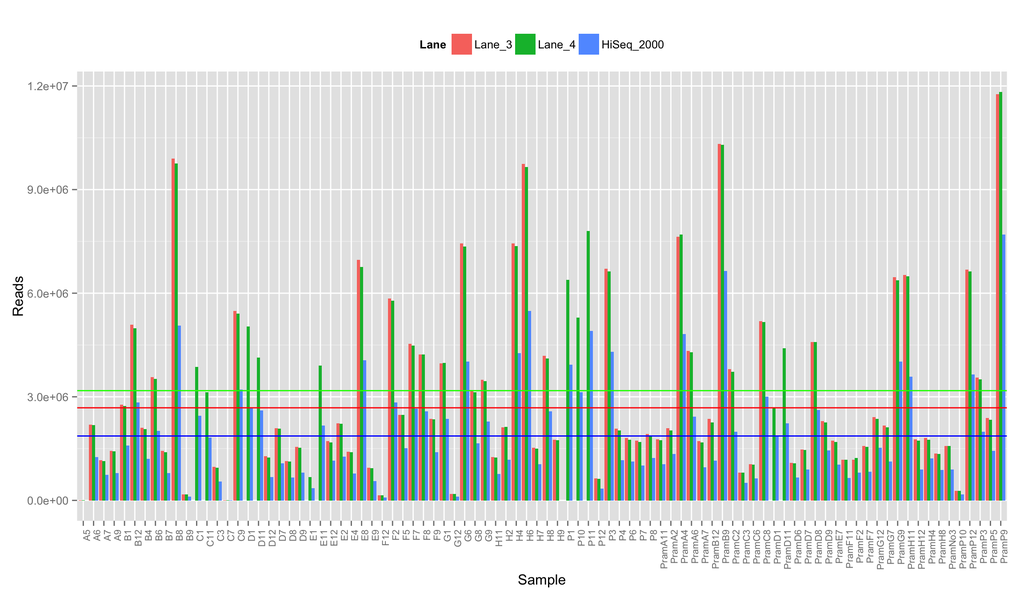

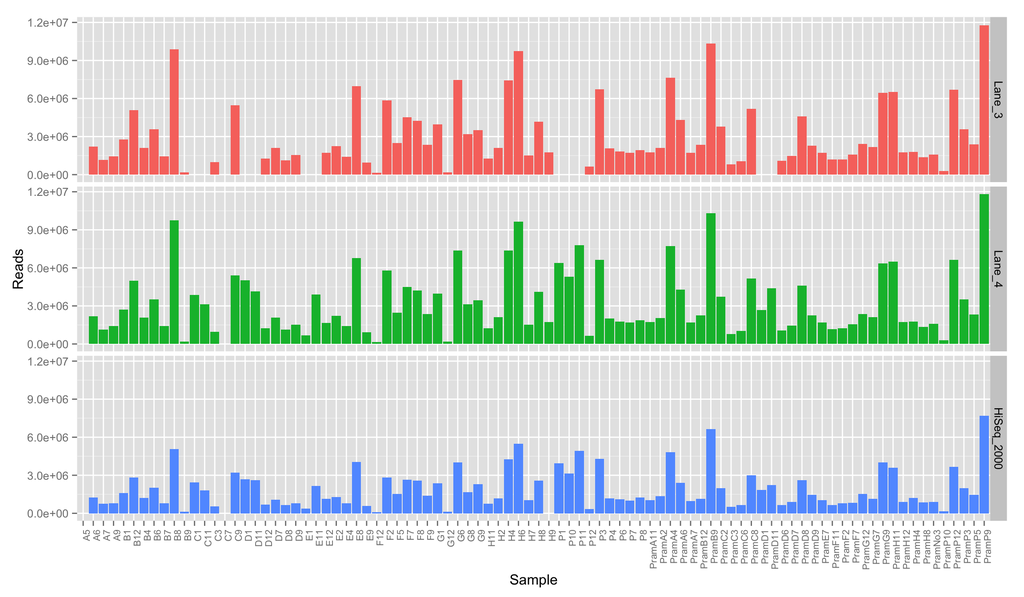

### Analisis of variance

There is an apparent higher number of reads on the **HiSeq-3000** lanes than in the **HiSeq-2000** samples. We tested for significance using an ANOVA.

|  | Df | Sum Sq | Mean Sq | F value | Pr(>F) |
| --- | --- | --- | --- | --- | --- |
| Lane | 2 | 7.911311e+13 | 3.955656e+13 | 7.55728 | 0.00064 |
| Residuals | 267 | 1.397541e+15 | 5.234234e+12 | NA | NA |

We see significant differences between treatments.

#### Tukey’s HSD test

|  | diff | lwr | upr | p adj |
| --- | --- | --- | --- | --- |
| Lane_3-HiSeq_2000 | 816400.1 | 12588.96 | 1620211 | 0.0455805 |
| Lane_4-HiSeq_2000 | 1313003.9 | 509192.74 | 2116815 | 0.0004336 |
| Lane_4-Lane_3 | 496603.8 | -307207.39 | 1300415 | 0.3138627 |

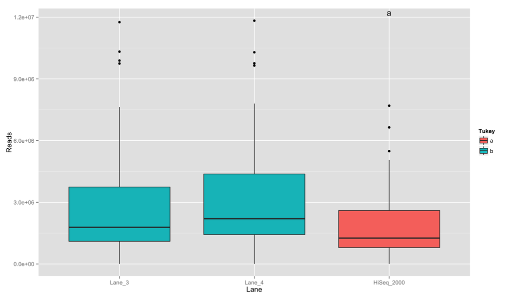

The differences are significant between the **HiSeq-2000** and the rest the treatments, while **Lane 3 and Lane 4** show no significant differences between them according to the Tukey HSD test.

### Correlation of reads between treatments

Let’s see if there is a correlation between the number of reads of the **HiSeq-2000** and each of the lanes of the **HiSeq-3000**.

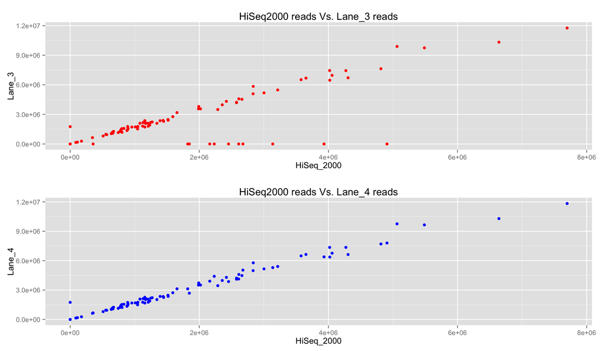

We can see a correlation between the number of reads in both methods, so samples with higher number of reads in the HiSeq-2000 are also the most represented in HiSeq-3000. **Sample concentration?**

## Mapping and aligning to the reference genome

### Proportion of reads mapped

Here, we are mapping the **proportion of reads mapped to the reference fragmented genome**:

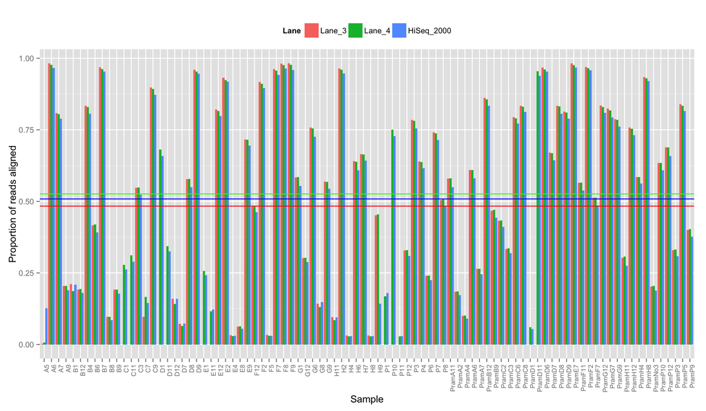

There is no evident change between the proportion of mapped reads between methods. To test this we are doing an analysis of variance:

|  | Df | Sum Sq | Mean Sq | F value | Pr(>F) |
| --- | --- | --- | --- | --- | --- |
| Lane | 2 | 0.08209 | 0.04104 | 0.38715 | 0.67937 |
| Residuals | 267 | 28.30681 | 0.10602 | NA | NA |

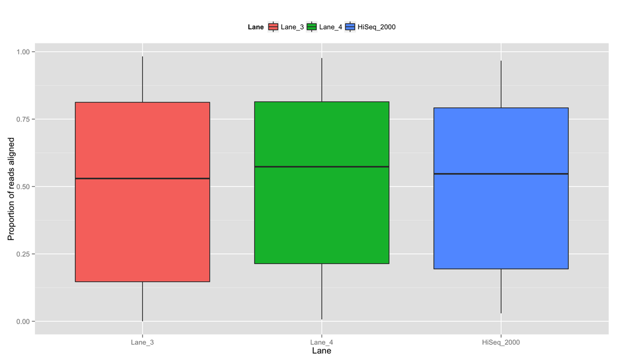

There are no significant differences between the proportion of aligned reads, indicating that the reads we are obtaining are of equal quality when compared to the reference genome. Its important to mention that even if the quality of the reads is similar between the two methods, there are still a higher number of reads in the **HiSeq-3000** approach. To test the average **coverage per nucleotide** between treatments we are going to use `samtools ::: mpileup`.

### Proportion of nucleotides mapped

After obtaining the pileups from `samtools`, we assessed coverage per sample by measuring summary stats and percentage of nucleotides with X coverage per site:

#### Coverage:

Coverage summary stats per sample

|  | mean | median | sd |
| --- | --- | --- | --- |
| Lane_3 | 6.363 | 5.039 | 4.779 |
| Lane_4 | 6.924 | 5.417 | 4.548 |
| HiSeq_2000 | 4.811 | 4.028 | 2.932 |

**Analysis of variance:** Coverage vs. Lane

|  | Df | Sum Sq | Mean Sq | F value | Pr(>F) |
| --- | --- | --- | --- | --- | --- |
| Lane | 2 | 215.5771 | 107.78854 | 6.20471 | 0.00232 |
| Residuals | 267 | 4638.3408 | 17.37206 | NA | NA |

We see significant differences between treatments.

**Tukey’s HSD test**

|  | diff | lwr | upr | p adj |
| --- | --- | --- | --- | --- |
| Lane_3-HiSeq_2000 | 1.5514164 | 0.0870386 | 3.015794 | 0.0349468 |
| Lane_4-HiSeq_2000 | 2.1127877 | 0.6484099 | 3.577166 | 0.0022317 |
| Lane_4-Lane_3 | 0.5613713 | -0.9030066 | 2.025749 | 0.6385623 |

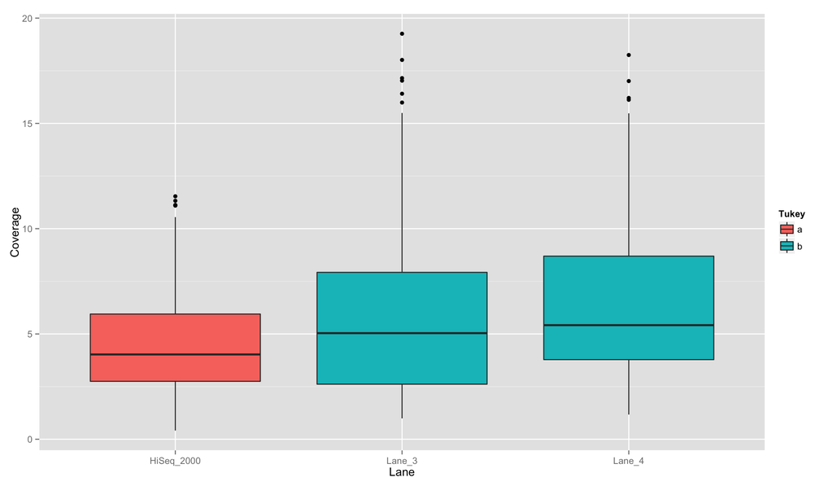

We can conclude that there are significant differences between HiSeq-3000 coverage and the HiSeq-2000 technology. If combined, the HiSeq-3000 technology can reach a average coverage as high as 10x, which is impressive for 2 lanes of Illumina. More information should be obtained about the capacity of using 2 lanes instead of one.

## Number of nucleotides with at least 4x coverage

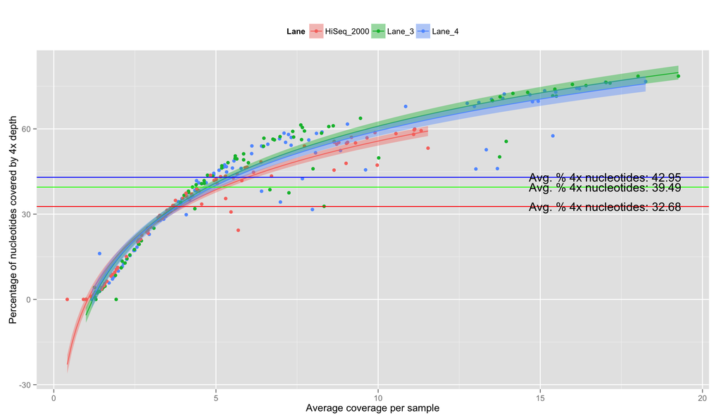

We can conclude a couple things from these results:

1. The average percentage of nucleotides coverage by 4x depth are:
- Lane_3: 39,49%
- Lane_4: 42.95%
- HiSeq-2000: 32.68%
2. We can infer that the HiSeq-3000 technology yields a higher number of 4x covered nucleotides than HiSeq-2000
3. Nonetheless, there is a decrease of the Y axis after the average coverage surpasses 5x. This shows that, to achieve a higher percentage of reads mapped to 4x depth, we will need to increase the average coverage by more (much more) than 20x.
4. The recommended approach will be to aim to a depth of 15x-20x to have more than 60% of the nucleotides covered 4 times (these results are concordant to the result found in [*P. rubi* using the HiSeq-2000 technology](http://tabima.github.io/GBS/Per_base_coverage.html)).

# Conclusions

- HiSeq-3000 analyses yield higher read numbers, average coverage and number of nucleotides sequences at a deeper depth than HiSeq-2000
- There are no differences in the number of mapped reads between the two technologies. This shows that the main difference between 2000 and 3000 is in the yield numbers
- No differences were found between the lanes of HiSeq-3000 for any of the measurements taken here.
- HiSeq-3000 may be the better way to go for GBS.

# Perspectives and questions (For Aaron and Matthew)

- Number of SNP’s called + quality: In Progress (running `GATK`)
- Can we combine HiSeq-3000 lanes to have a higher coverage?
- There is a correlation of sample with low reads in HiSeq-2000 and HiSeq-3000, has this anything to do with the DNA concentration/quality sent to the CGRB?

- Sorting: 3 days
- Mapping: 2 days
- Pileups: 2 days
- R counts, data import and scripting: 1 week
- Importing pileups to R: 8 hours (classical), 3 hours (fread), 1 hour (Simplifying the input)
- Analysis and results: 2 days, 7 hours.